# Survival analysis

2023-07-23

Read the data.

```r
turnover <- read.csv("C:/Users/Tanji/Downloads/archive/turnover.csv", stringsAsFactors=TRUE) #read data
```

# EDA

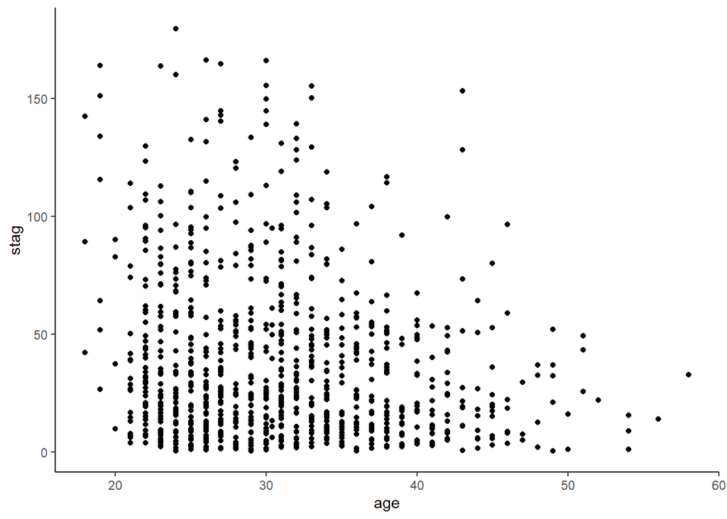

```r
# Scatter-plots:
ggplot(data = turnover, aes(age, stag)) +
  geom_point() +
  theme_classic()
```

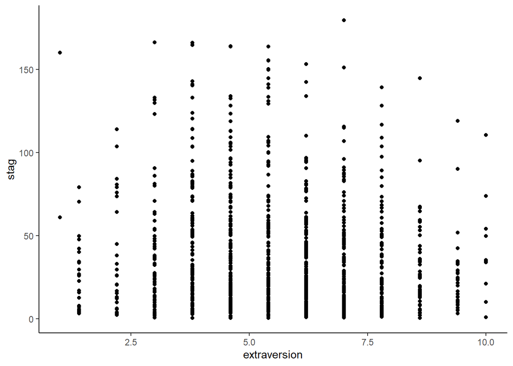

```r
ggplot(data = turnover, aes(extraversion, stag)) +
  geom_point() +
  theme_classic()
```

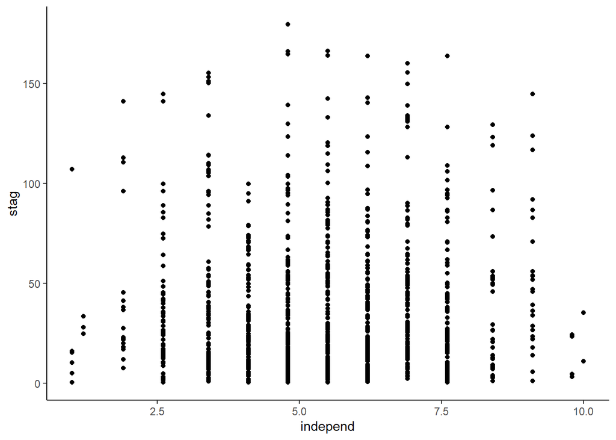

```r
ggplot(data = turnover, aes(independ, stag)) +
  geom_point() +
  theme_classic()
```

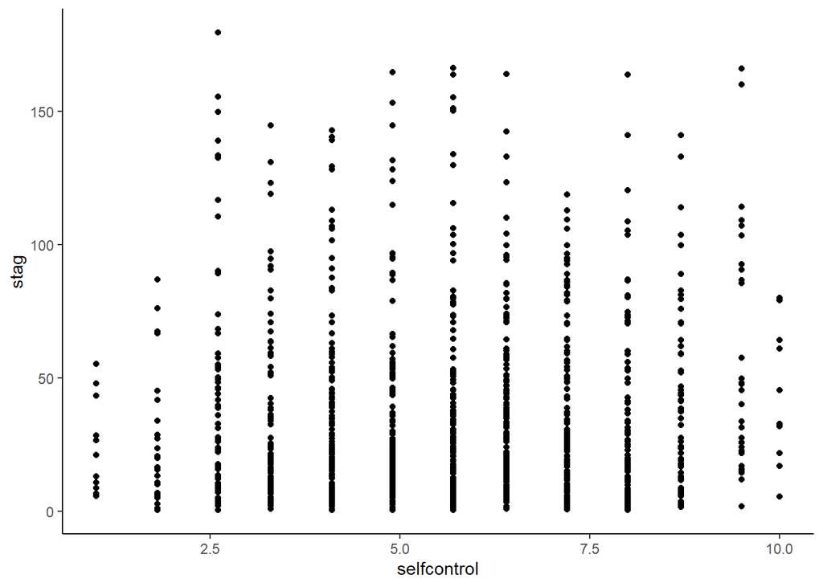

```r
ggplot(data = turnover, aes(selfcontrol, stag)) +
  geom_point() +
  theme_classic()
```

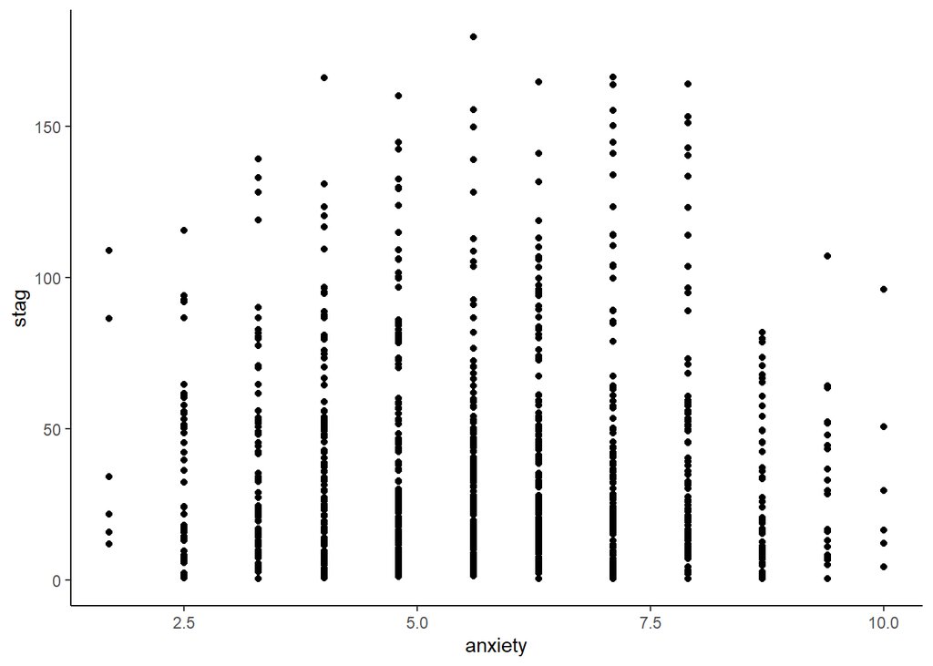

```r
ggplot(data = turnover, aes(anxiety, stag)) +
  geom_point() +
  theme_classic()
```

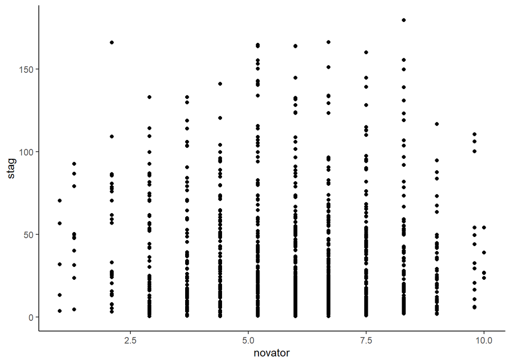

```r
ggplot(data = turnover, aes(novator, stag)) +
  geom_point() +
  theme_classic()
```

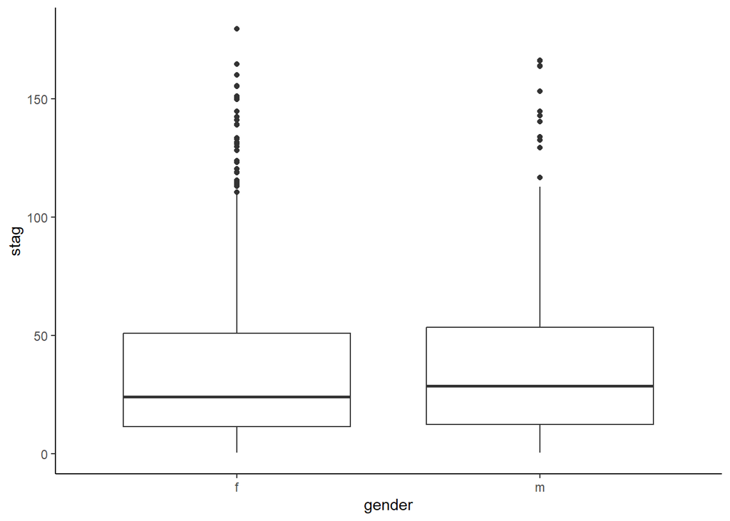

```r
# Box-plots:

ggplot(data = turnover, aes(gender, stag)) +
  geom_boxplot() +
  theme_classic()
```

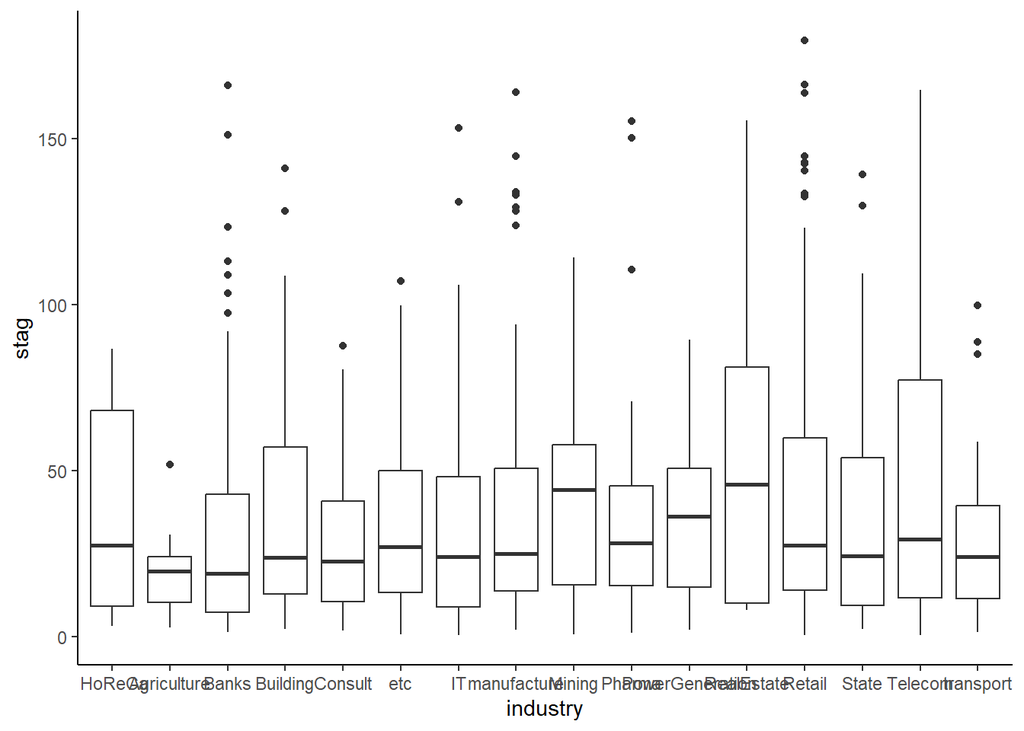

```r
ggplot(data = turnover, aes(industry, stag)) +
  geom_boxplot() +
  theme_classic()
```

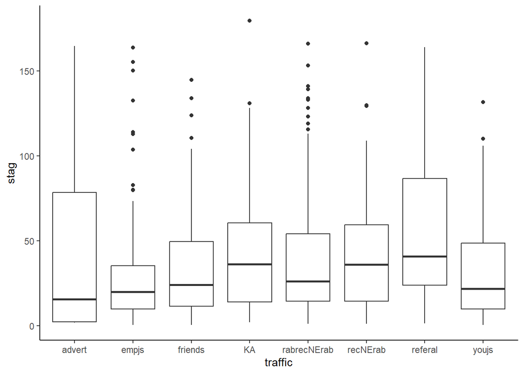

```r
ggplot(data = turnover, aes(traffic, stag)) +
  geom_boxplot() +
  theme_classic()
```

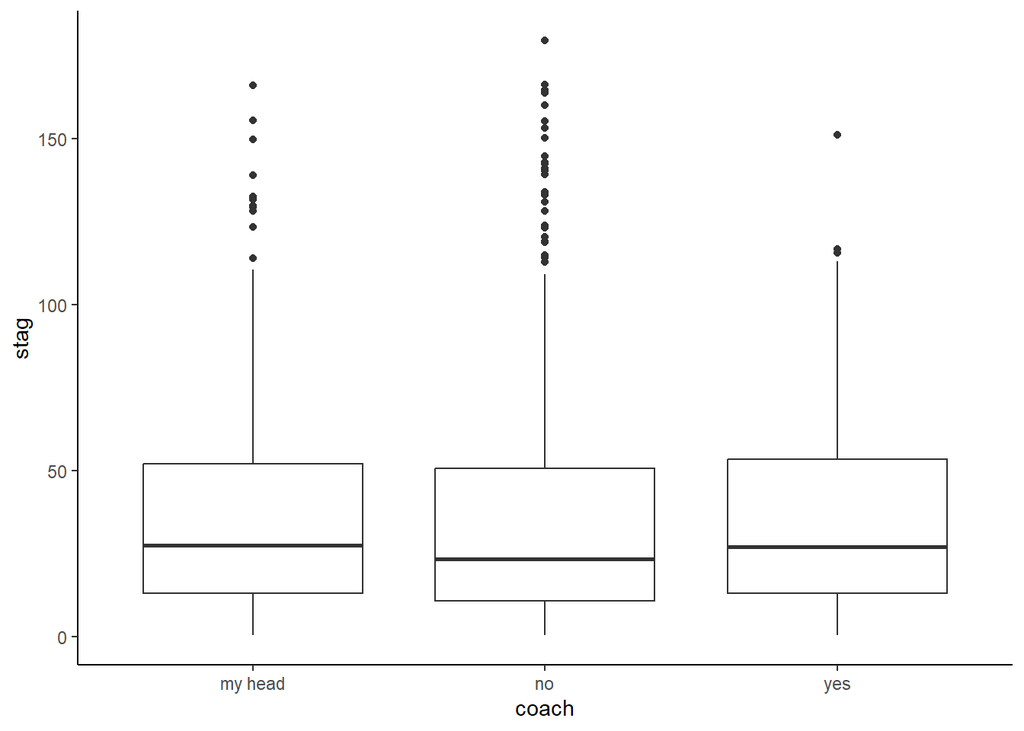

```r
ggplot(data = turnover, aes(coach, stag)) +
  geom_boxplot() +
  theme_classic()
```

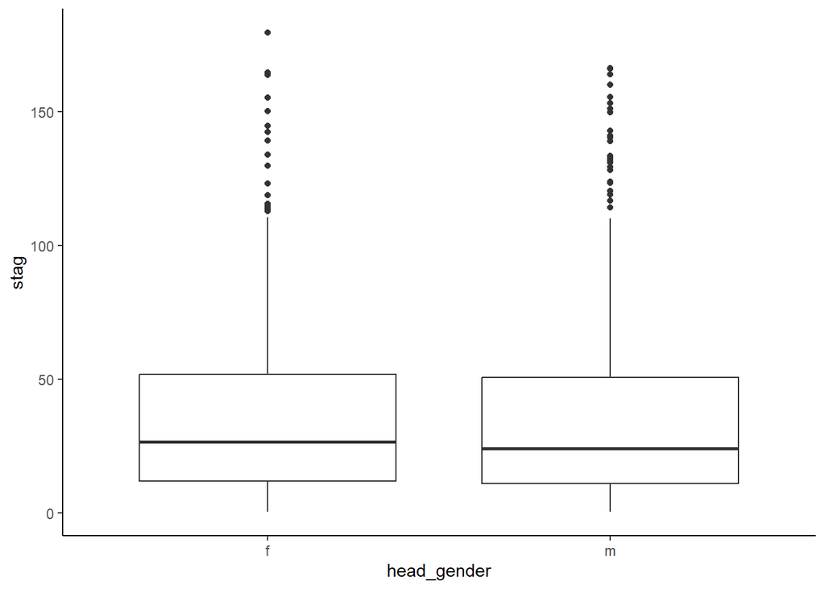

```r
ggplot(data = turnover, aes(head_gender, stag)) +
  geom_boxplot() +
  theme_classic()
```

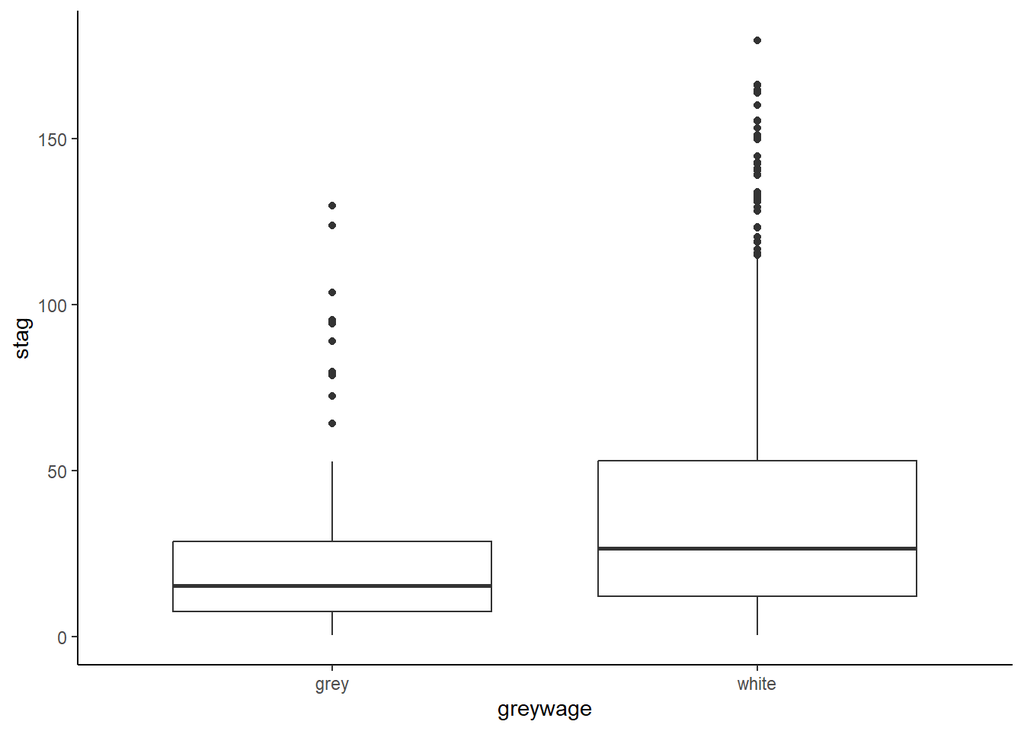

```r
ggplot(data = turnover, aes(greywage, stag)) +
  geom_boxplot() +
  theme_classic()
```

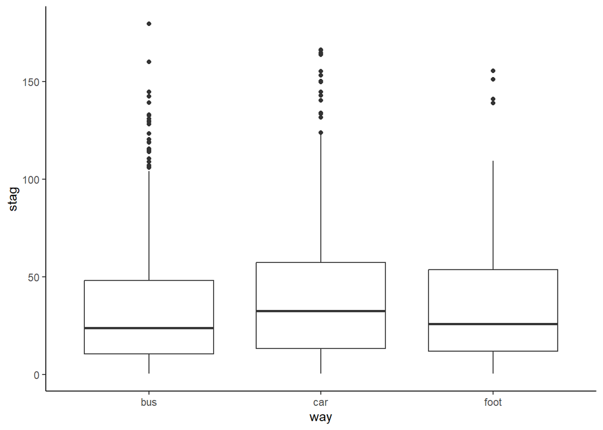

```r
ggplot(data = turnover, aes(way, stag)) +
  geom_boxplot() +
  theme_classic()
```

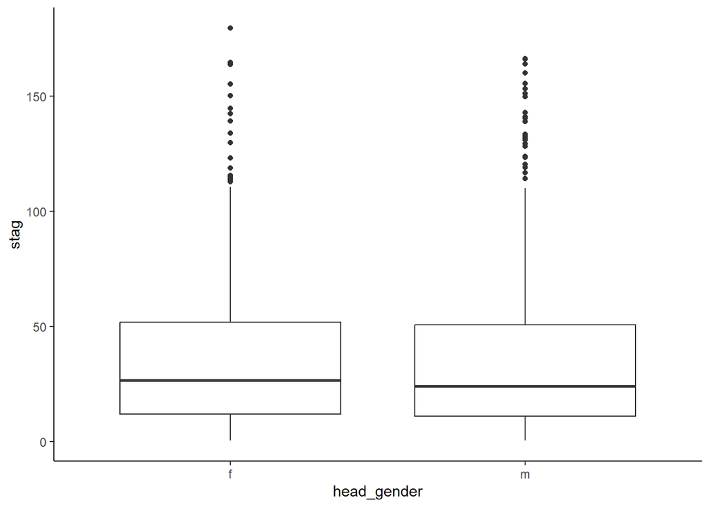

```r
ggplot(data = turnover, aes(head_gender, stag)) +
  geom_boxplot() +
  theme_classic()
```

```r
# Data description
str(turnover)
```

```
## 'data.frame':    1129 obs. of  16 variables:
##  $ stag        : num  7.03 22.97 15.93 15.93 8.41 ...
##  $ event       : int  1 1 1 1 1 1 1 1 1 1 ...
##  $ gender      : Factor w/ 2 levels "f","m": 2 2 1 1 2 1 1 1 1 1 ...
##  $ age         : num  35 33 35 35 32 42 42 28 29 30 ...
##  $ industry    : Factor w/ 16 levels " HoReCa","Agriculture",..: 3 3 11 11 13 8 8 13 3 5 ...
##  $ profession  : Factor w/ 15 levels "Finan\xf1e","Accounting",..: 8 8 8 8 4 8 8 8 8 12 ...
##  $ traffic     : Factor w/ 8 levels "advert","empjs",..: 5 2 5 5 8 2 2 7 2 8 ...
##  $ coach       : Factor w/ 3 levels "my head","no",..: 2 2 2 2 3 3 3 2 2 3 ...
##  $ head_gender : Factor w/ 2 levels "f","m": 1 2 2 2 1 2 2 2 1 2 ...
##  $ greywage    : Factor w/ 2 levels "grey","white": 2 2 2 2 2 2 2 2 2 2 ...
##  $ way         : Factor w/ 3 levels "bus","car","foot": 1 1 1 1 1 1 1 1 1 1 ...
##  $ extraversion: num  6.2 6.2 6.2 5.4 3 6.2 6.2 3.8 8.6 5.4 ...
##  $ independ    : num  4.1 4.1 6.2 7.6 4.1 6.2 6.2 5.5 6.9 5.5 ...
##  $ selfcontrol : num  5.7 5.7 2.6 4.9 8 4.1 4.1 8 2.6 3.3 ...
##  $ anxiety     : num  7.1 7.1 4.8 2.5 7.1 5.6 5.6 4 4 7.9 ...
##  $ novator     : num  8.3 8.3 8.3 6.7 3.7 6.7 6.7 4.4 7.5 8.3 ...
```

```r
table(turnover$event) #  0 = 558; 1 = 571
```

```
##
##   0   1
## 558 571
```

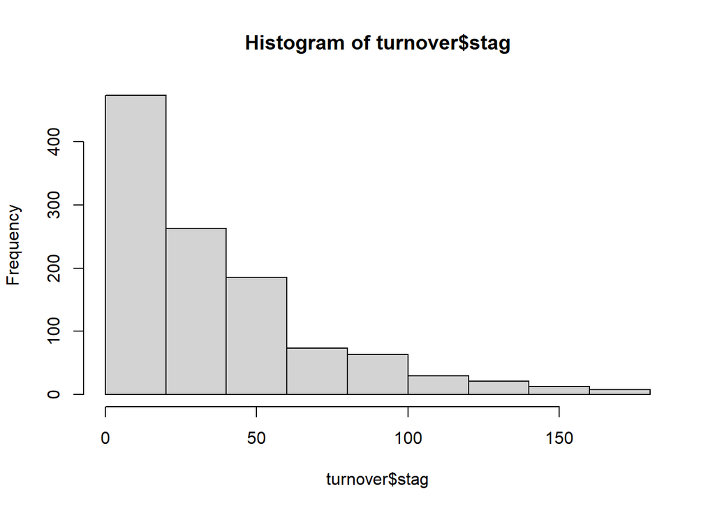

```r
# Histogram of employee's experience using both censored and non-censored data
hist(turnover$stag)
```

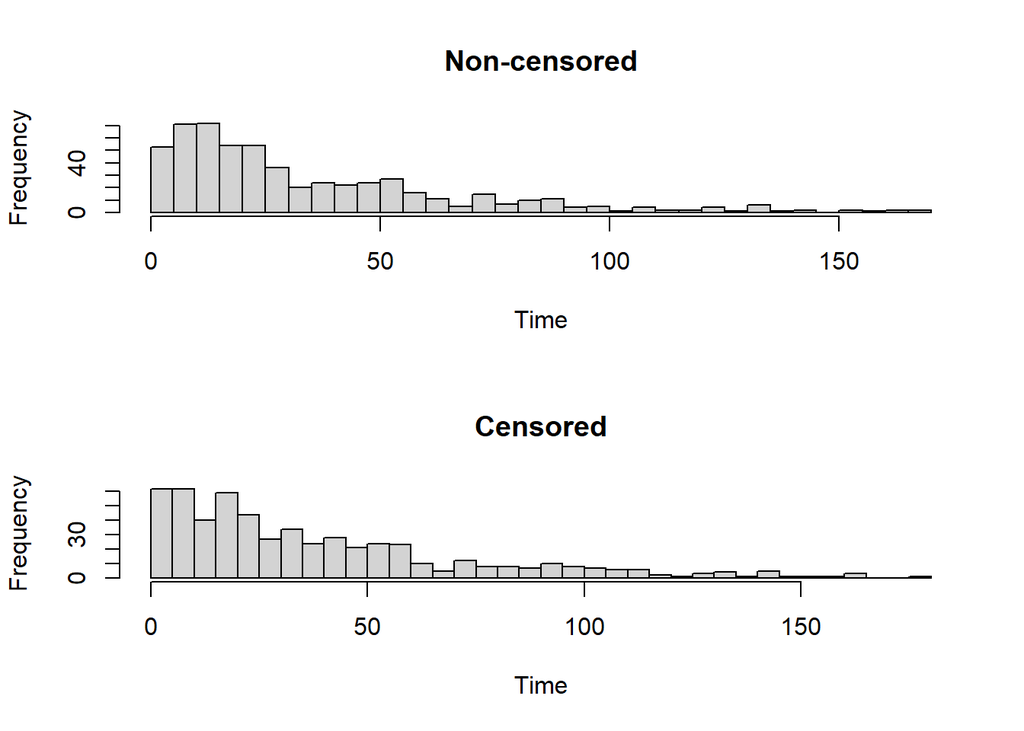

```r
# Histograms of employee's experience for censored and non-censored data separately
par(mfrow=c(2,1))
hist(as.matrix(turnover %>%
                 filter(event==1) %>%
                 select(stag)),
     breaks = 30, xlab="Time", main="Non-censored")

hist(as.matrix(turnover %>%
                 filter(event==0) %>%
                 select(stag)),
     breaks = 30, xlab="Time", main="Censored")
```

# Kaplan-Meier estimator

```r
km_model <- survfit(Surv(turnover$stag, turnover$event) ~ 1)
#summary(km_model)
km_model2 <- survfit(Surv(turnover$stag, turnover$event) ~ turnover$gender) # independent var must be categorical
#summary(km_model2)
```

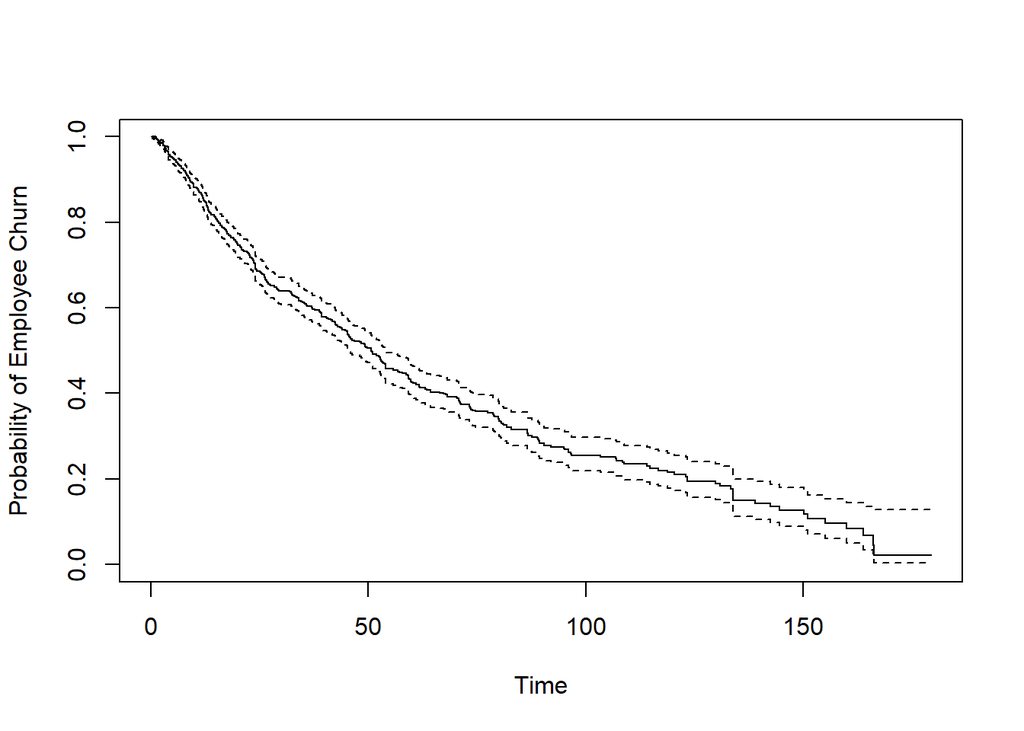

```r
# Plot 1
par(mfrow=c(1,1))
plot(km_model, xlab="Time", ylab="Probability of Employee Churn")
```

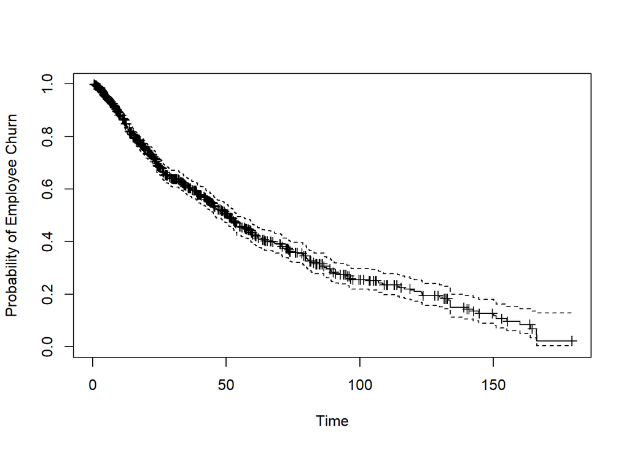

```r
# Plot 1.2. mark.time = T marks where there was a censored obs
plot(km_model, xlab="Time", ylab="Probability of Employee Churn", mark.time = T)
```

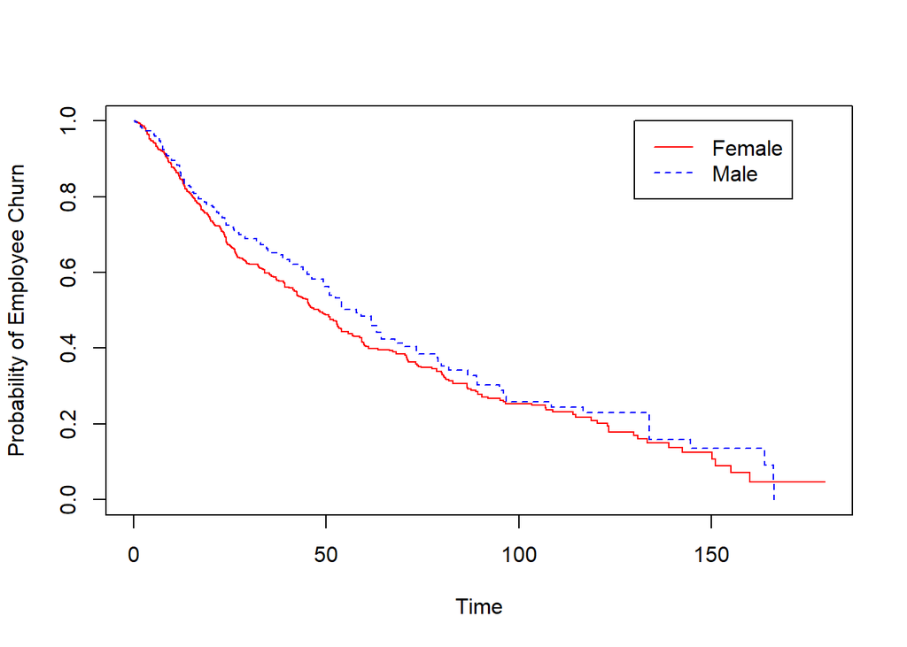

```r
# Plot 2
plot(km_model2,
     xlab="Time", ylab="Probability of Employee Churn", lty=1:2, col=c("red", "blue"))

legend(x = 130, y = 1, legend = c("Female", "Male"), lty=1:2, col=c("red", "blue"))
```

# log-rank test

H0: There is no significant difference in turnover time according to gender. In other words, survival in two groups in the same.

```r
survdiff(Surv(turnover$stag, turnover$event) ~ turnover$gender)
```

```
## Call:
## survdiff(formula = Surv(turnover$stag, turnover$event) ~ turnover$gender)
##
##                     N Observed Expected (O-E)^2/E (O-E)^2/V
## turnover$gender=f 853      436      420     0.614      2.35
## turnover$gender=m 276      135      151     1.706      2.35
##
##  Chisq= 2.3  on 1 degrees of freedom, p= 0.1
```

```r
# Results reveal (p = 0.1), we do not reject the H0. There is no significant difference in overall turnover according to gender.
```

# Cox HP Model

```r
cox_model <- coxph(Surv(turnover$stag, turnover$event) ~
                     turnover$age + turnover$gender + turnover$way + turnover$greywage + turnover$anxiety)

cox_model2 <- coxph(Surv(turnover$stag, turnover$event) ~
                     turnover$age + turnover$gender + turnover$way + turnover$greywage)

cox_model3 <- coxph(Surv(turnover$stag, turnover$event) ~
                      turnover$age + turnover$way + turnover$greywage)
```

ANOVA

H0: there is no significant difference between two models

```r
anova(cox_model, cox_model2, test="LRT") # p=0.1163, so we can drop anxiety
```

```
## Analysis of Deviance Table
##  Cox model: response is  Surv(turnover$stag, turnover$event)
##  Model 1: ~ turnover$age + turnover$gender + turnover$way + turnover$greywage + turnover$anxiety
##  Model 2: ~ turnover$age + turnover$gender + turnover$way + turnover$greywage
##    loglik  Chisq Df Pr(>|Chi|)
## 1 -3447.8
## 2 -3449.1 2.4662  1     0.1163
```

```r
anova(cox_model2, cox_model3, test="LRT") # p=0.1712, so we can drop gender
```

```
## Analysis of Deviance Table
##  Cox model: response is  Surv(turnover$stag, turnover$event)
##  Model 1: ~ turnover$age + turnover$gender + turnover$way + turnover$greywage
##  Model 2: ~ turnover$age + turnover$way + turnover$greywage
##    loglik  Chisq Df Pr(>|Chi|)
## 1 -3449.1
## 2 -3450.0 1.8721  1     0.1712
```

Summary of the model.

One year older employee is 2.14% is more likely to turnover than one year younger, given the same way and wage.

Those who travel by car are 20.64% (1-0.7936 = 0.2064) less likely to turnover than those who get to work by bus.

Those who travel by foot are 32.84% (1-0.6716 = 0.3284) less likely to turnover than those who get to work by bus.

Those who get white wage are 40.92% (1-0.5908 = 0.4092) less likely to turnover than those who get grey wage.

LLR test and Wald test reveal (p<<.001) model is significant.

Concordance measures, how good the model is in predicting longer survival for those who indeed survived longer.

```r
summary(cox_model3)
```

```
## Call:
## coxph(formula = Surv(turnover$stag, turnover$event) ~ turnover$age +
##     turnover$way + turnover$greywage)
##
##   n= 1129, number of events= 571
##
##                             coef exp(coef)  se(coef)      z Pr(>|z|)
## turnover$age            0.021209  1.021435  0.006054  3.503 0.000459 ***
## turnover$waycar        -0.231184  0.793594  0.093790 -2.465 0.013704 *
## turnover$wayfoot       -0.398139  0.671569  0.162533 -2.450 0.014302 *
## turnover$greywagewhite -0.526307  0.590782  0.126872 -4.148 3.35e-05 ***
## ---
## Signif. codes:  0 '***' 0.001 '**' 0.01 '*' 0.05 '.' 0.1 ' ' 1
##
##                        exp(coef) exp(-coef) lower .95 upper .95
## turnover$age              1.0214      0.979    1.0094    1.0336
## turnover$waycar           0.7936      1.260    0.6603    0.9537
## turnover$wayfoot          0.6716      1.489    0.4884    0.9235
## turnover$greywagewhite    0.5908      1.693    0.4607    0.7576
##
## Concordance= 0.581  (se = 0.014 )
## Likelihood ratio test= 40.58  on 4 df,   p=3e-08
## Wald test            = 43.83  on 4 df,   p=7e-09
## Score (logrank) test = 44.55  on 4 df,   p=5e-09
```

```r
# tbl_regression() function provides a more accurate table with results.
cox_model3 %>%
  tbl_regression(exp = TRUE)
```

| **Characteristic** | **HR**<sup>1</sup> | **95% CI**<sup>1</sup> | **p-value** |
| --- | --- | --- | --- |
| turnover$age | 1.02 | 1.01, 1.03 | <0.001 |
| turnover$way |  |  |  |
| bus | — | — |  |
| car | 0.79 | 0.66, 0.95 | 0.014 |
| foot | 0.67 | 0.49, 0.92 | 0.014 |
| turnover$greywage |  |  |  |
| grey | — | — |  |
| white | 0.59 | 0.46, 0.76 | <0.001 |

<sup>1</sup> HR = Hazard Ratio, CI = Confidence Interval

# 1. Linearity assumption.

Numerical independent variable and Log(hazard) must be linearly related.

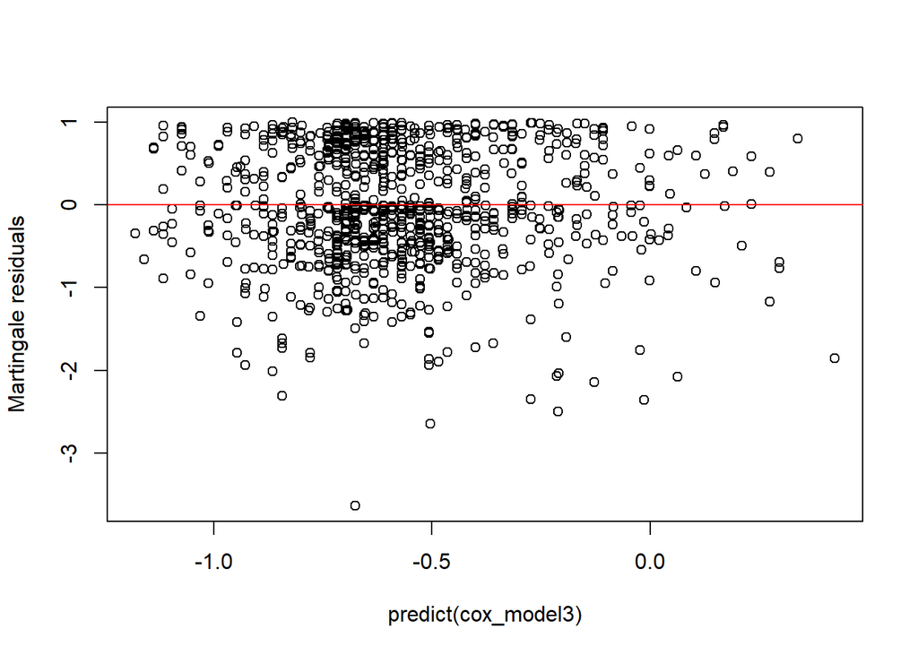

```r
plot(predict(cox_model3), residuals(cox_model3, type = "martingale"), ylab="Martingale residuals")
abline(h=0, col="red")
```

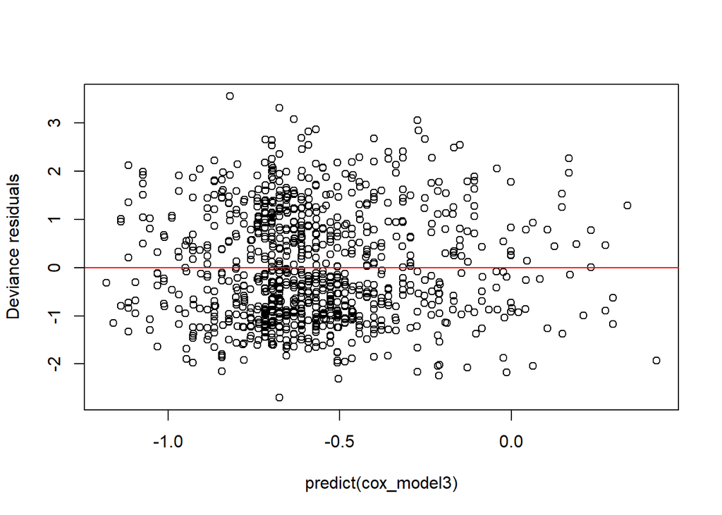

```r
plot(predict(cox_model3), residuals(cox_model3, type = "deviance"), ylab="Deviance residuals")
abline(h=0, col="red")
```

# 2. Proportional hazards assumption.

Schoenfeld test.

H0: Hazards are proportional

```r
(zph <- cox.zph(cox_model3)) # p=0.65, Hazards are proportional, assumption is met.
```

```
##                   chisq df    p
## turnover$age      0.227  1 0.63
## turnover$way      0.518  2 0.77
## turnover$greywage 1.640  1 0.20
## GLOBAL            2.482  4 0.65
```

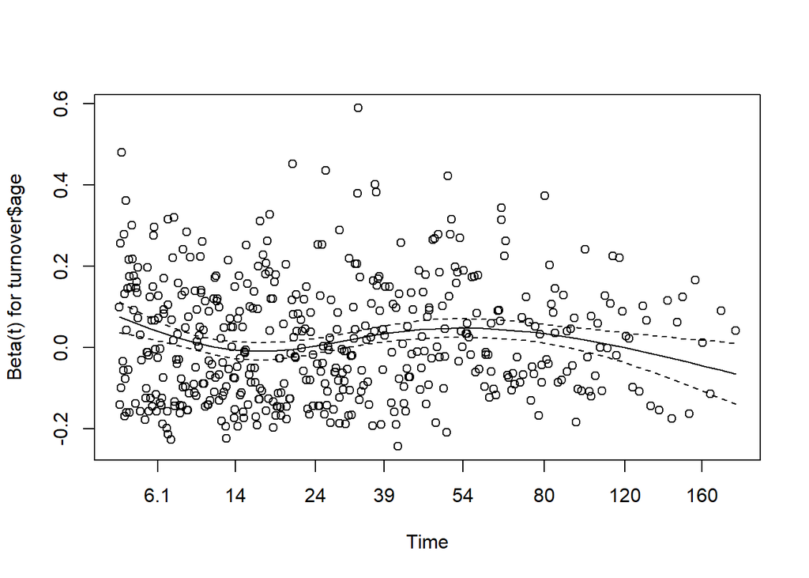

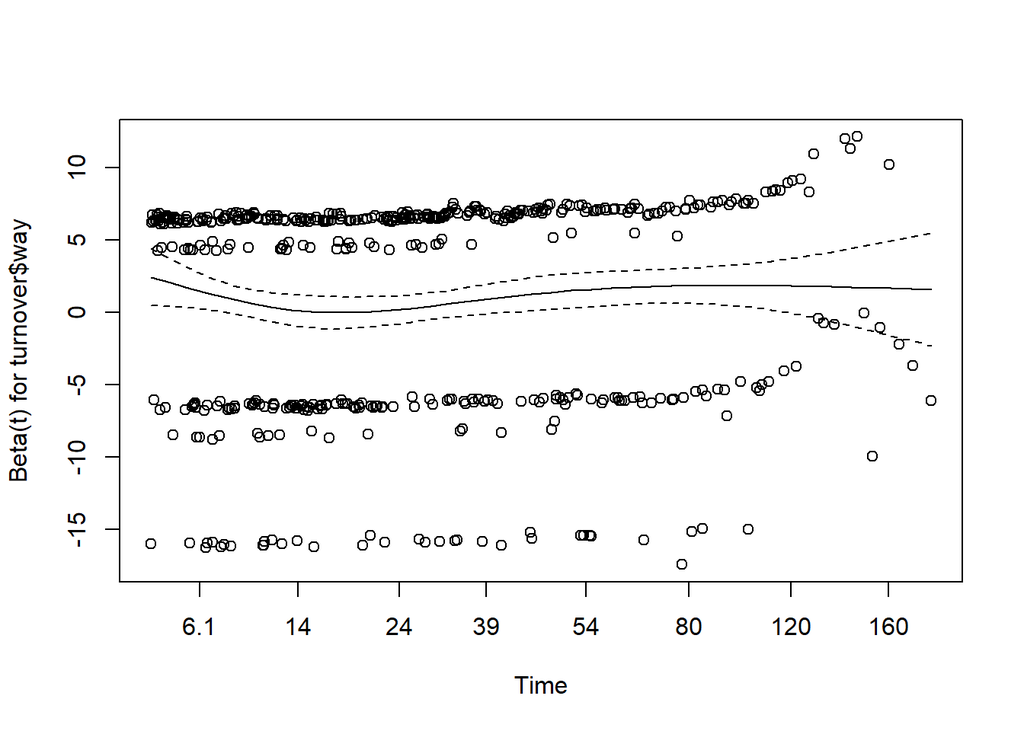

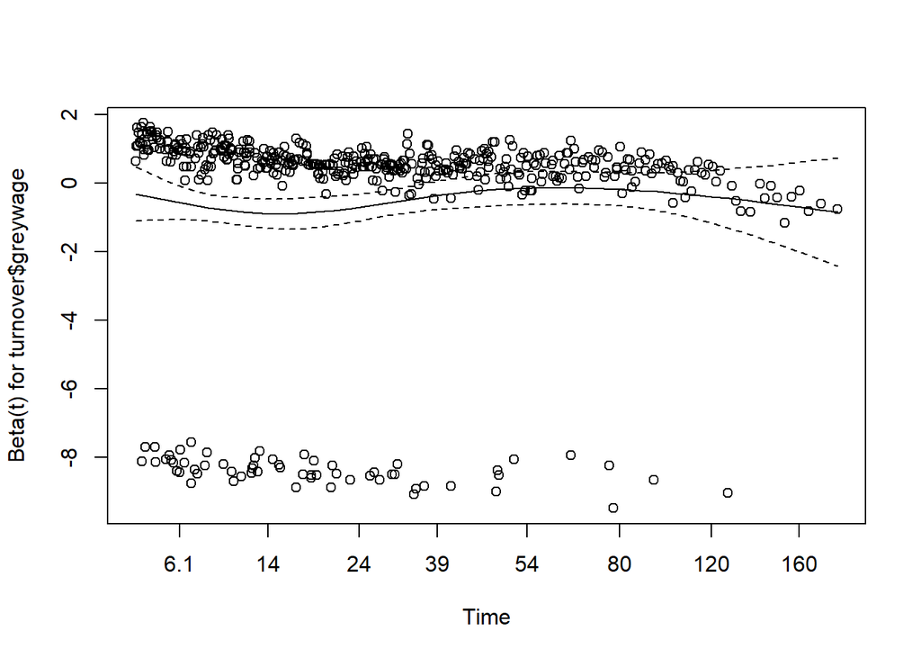

```r
# Plots of the Schoenfeld residual. Deviation from a zero Y-value line assumes violation of the assumption.
plot(zph)
```